# Second Session

101410 - Asoka Niyonsaba Jean Claude

2025-10-16

# CLASS 2 & 3:DATA VISUALIZATION

# AND DATA MANAGEMENT

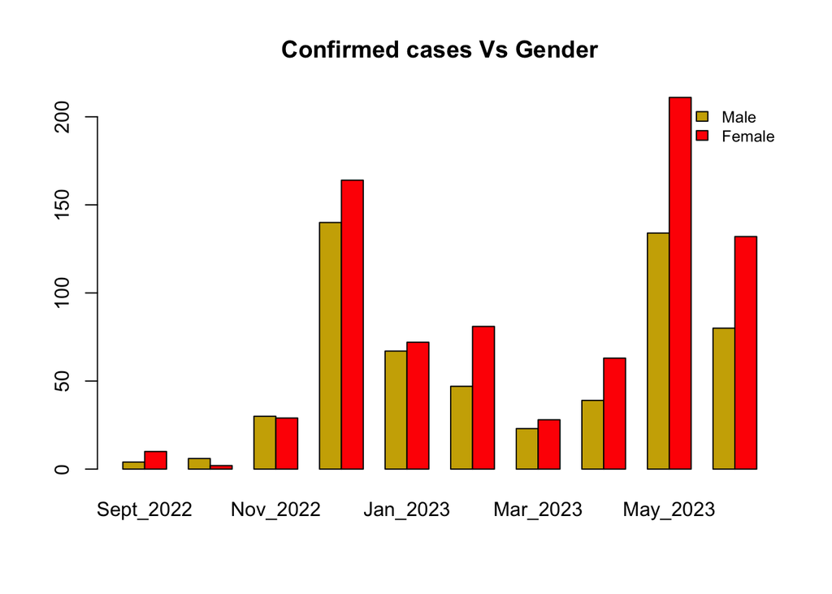

```r
data1 <- read.table(text="
Sept_2022 Oct_2022 Nov_2022 Dec_2022 Jan_2023 Feb_2023 Mar_2023 Apr_2023 May_2023 June_2023
1 4 6 30 140 67 47 23 39 134 80
2 10 2 29 164 72 81 28 63 211 132
", header = TRUE)

barplot(as.matrix(data1),
        main = "Confirmed cases Vs Gender",
        beside = TRUE,
        col = c("gold3", "red"))

legend("topright",
       c("Male", "Female"),
       cex = 0.8,
       bty = "n",
       fill = c("gold3", "red"))
```

```r
# Create the dataset correctly
data3 <- read.table(text = "
Month       Male  Female
Sept_2022   867   582
Oct_2022    1802  12003
Nov_2022    3059  9205
Dec_2022    5346  7269
Jan_2023    5933  3245
Feb_2023    842   436
Mar_2023    1805  11785
Apr_2023    3508  10908
May_2023    4902  7883
June_2023   5901  4646
", header = TRUE)

# View data
print(data3)
```

```
##        Month Male Female
## 1  Sept_2022  867    582
## 2   Oct_2022 1802  12003
## 3   Nov_2022 3059   9205
## 4   Dec_2022 5346   7269
## 5   Jan_2023 5933   3245
## 6   Feb_2023  842    436
## 7   Mar_2023 1805  11785
## 8   Apr_2023 3508  10908
## 9   May_2023 4902   7883
## 10 June_2023 5901   4646
```

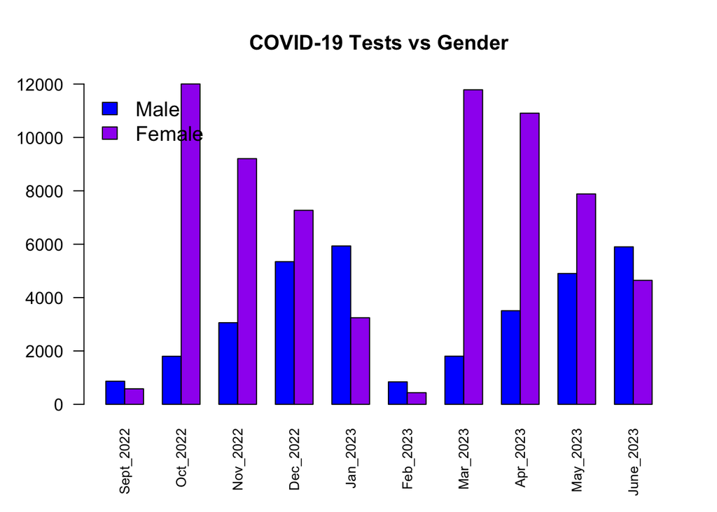

```r
# Create bar plot
barplot(
  as.matrix(t(data3[, -1])),                     # transpose so months are grouped
  beside = TRUE,
  col = c("blue", "purple"),
  names.arg = data3$Month,
  main = "COVID-19 Tests vs Gender",
  las = 2,                                       # make month labels vertical
  cex.names = 0.8
)

# Add legend
legend("topleft",
       legend = c("Male", "Female"),
       cex = 1.2,
       bty = "n",
       fill = c("blue", "purple"))
```

```r
# Create the dataset correctly
data2 <- read.table(text = "
Month       Less_15  Age_15_49  Above_50
Sept_2022   0        11         3
Oct_2022    0        3          5
Nov_2022    1        41         17
Dec_2022    9        242        53
Jan_2023    8        104        27
Feb_2023    7        78         43
Mar_2023    1        44         6
Apr_2023    4        86         12
May_2023    11       244        90
June_2023   22       147        43
", header = TRUE)

# View the data
print(data2)
```

```
##        Month Less_15 Age_15_49 Above_50
## 1  Sept_2022       0        11        3
## 2   Oct_2022       0         3        5
## 3   Nov_2022       1        41       17
## 4   Dec_2022       9       242       53
## 5   Jan_2023       8       104       27
## 6   Feb_2023       7        78       43
## 7   Mar_2023       1        44        6
## 8   Apr_2023       4        86       12
## 9   May_2023      11       244       90
## 10 June_2023      22       147       43
```

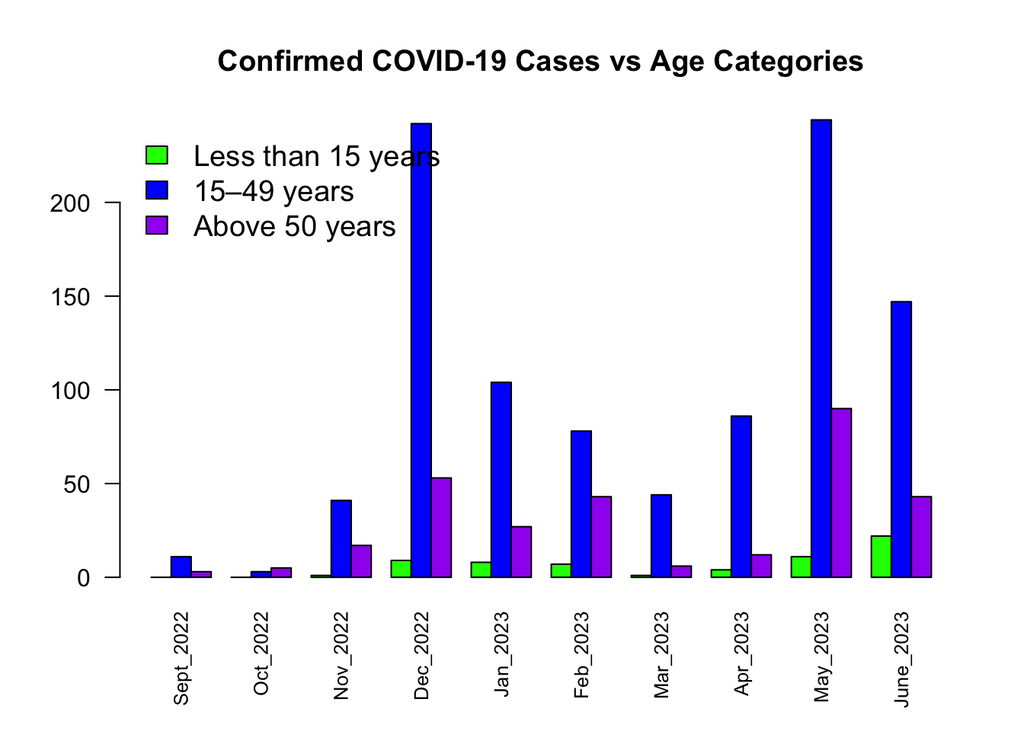

```r
# Create bar plot
barplot(
  as.matrix(t(data2[, -1])),          # transpose numeric data for side-by-side bars
  beside = TRUE,
  col = c("green", "blue", "purple"),
  names.arg = data2$Month,
  main = "Confirmed COVID-19 Cases vs Age Categories",
  las = 2,                            # rotate month labels for clarity
  cex.names = 0.8
)

# Add legend
legend("topleft",
       legend = c("Less than 15 years", "15–49 years", "Above 50 years"),
       cex = 1.2,
       bty = "n",
       fill = c("green", "blue", "purple"))
```

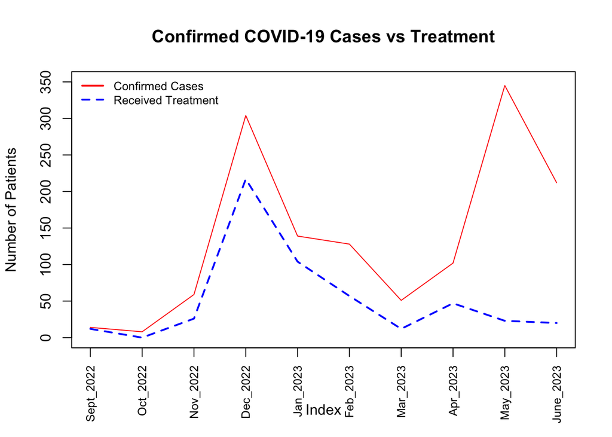

```r
# Define the months
months <- c("Sept_2022", "Oct_2022", "Nov_2022", "Dec_2022",
            "Jan_2023", "Feb_2023", "Mar_2023", "Apr_2023",
            "May_2023", "June_2023")

# Data for confirmed COVID cases
Confirmed_covid <- c(14, 8, 59, 304, 139, 128, 51, 102, 345, 212)

# Data for patients who received treatment
treatment <- c(12, 0, 26, 217, 104, 57, 12, 47, 23, 20)

# Create the line plot
plot(Confirmed_covid,
     type = "l",               # line plot
     pch = 21,                 # point style
     col = "red",              # line color
     ylim = c(0, 350),         # y-axis range
     xaxt = "n",               # suppress x-axis temporarily
     ylab = "Number of Patients",
     main = "Confirmed COVID-19 Cases vs Treatment")

# Add the second line (treatment)
lines(treatment, col = "blue", lty = 2, lwd = 2)

# Add x-axis labels
axis(1, at = 1:10, labels = months, las = 2, cex.axis = 0.8)

# Add legend
legend("topleft",
       legend = c("Confirmed Cases", "Received Treatment"),
       col = c("red", "blue"),
       lty = c(1, 2),
       lwd = 2,
       bty = "n",
       cex = 0.8)
```

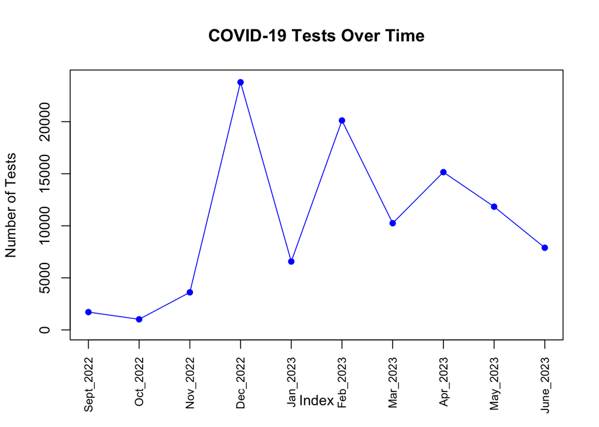

```r
# Define months
months <- c("Sept_2022", "Oct_2022", "Nov_2022", "Dec_2022",
            "Jan_2023", "Feb_2023", "Mar_2023", "Apr_2023",
            "May_2023", "June_2023")

# Define number of COVID-19 tests
number_of_test <- c(1709, 1018, 3607, 23788, 6567, 20113, 10248, 15152, 11834, 7891)

# Create line and point plot
plot(number_of_test,
     type = "o",                # "o" means line + points
     col = "blue",              # line color
     pch = 16,                  # solid circle points
     ylim = c(0, 24000),        # y-axis limits
     xaxt = "n",                # hide x-axis for now
     ylab = "Number of Tests",
     main = "COVID-19 Tests Over Time")

# Add month names on x-axis
axis(1, at = 1:10, labels = months, las = 2, cex.axis = 0.8)
```

ggplot2 ggplot2 provides a set of tools that allows you to visualize complex data sets in a new creative way-some work need some packages to get done.-some of the graph are created using R’s base graphics system

```r
###install.packages("ggplot2")
 library(ggplot2)
data(mtcars)
 #dotchart(mtcars$mpg,labels=row.names(mtcars),ce#x = 0.,main="miles per Gallon of car #model",xlab = "MPG")
 table(mtcars$cyl)
```

```
##
##  4  6  8
## 11  7 14
```

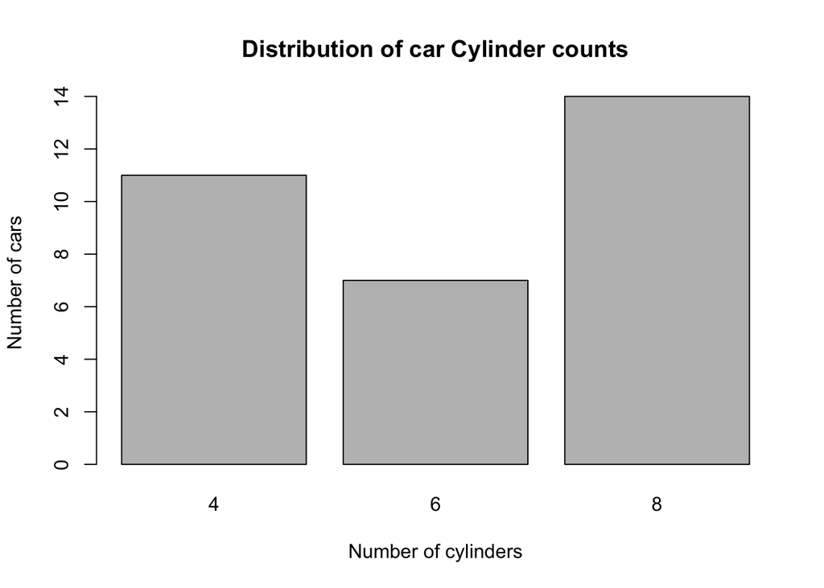

```r
 #barplot(mtcars$cyl)
 barplot(table(mtcars$cyl),main="Distribution of car Cylinder counts",xlab="Number of cylinders",ylab = "Number of cars")
```

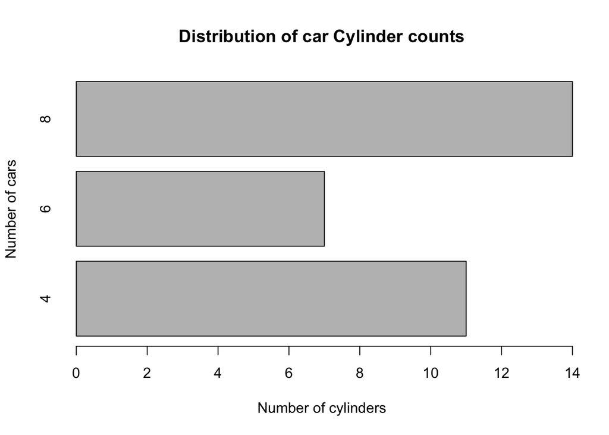

```r
barplot(table(mtcars$cyl),main="Distribution of car Cylinder counts",xlab="Number of cylinders",ylab = "Number of cars",horiz=TRUE)
```

```r
plot(mtcars$mpg~mtcars$wt,main="Automobile Data",xlab="Weight",ylab=" Miles per Gallon")
```

[output not shown]

```r
plot(mtcars$mpg~mtcars$wt,main="Automobile Data",xlab="Weight",ylab=" Miles per Gallon")
```

[output not shown]

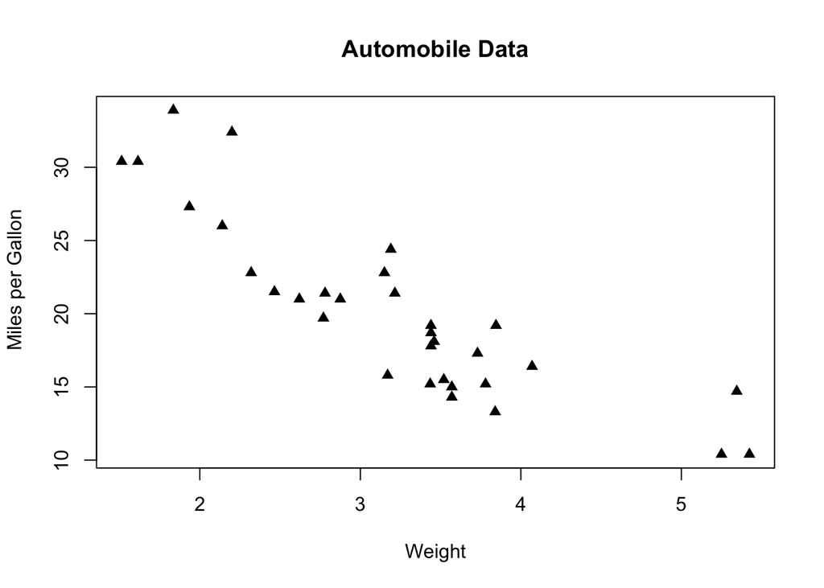

```r
plot(mtcars$mpg~mtcars$wt,pch=17,main="Automobile Data",xlab="Weight",ylab=" Miles per Gallon")
```

```r
plot(mtcars$mpg~mtcars$wt,pch=21,main="Automobile Data",xlab="Weight",ylab=" Miles per Gallon")
```

[output not shown]

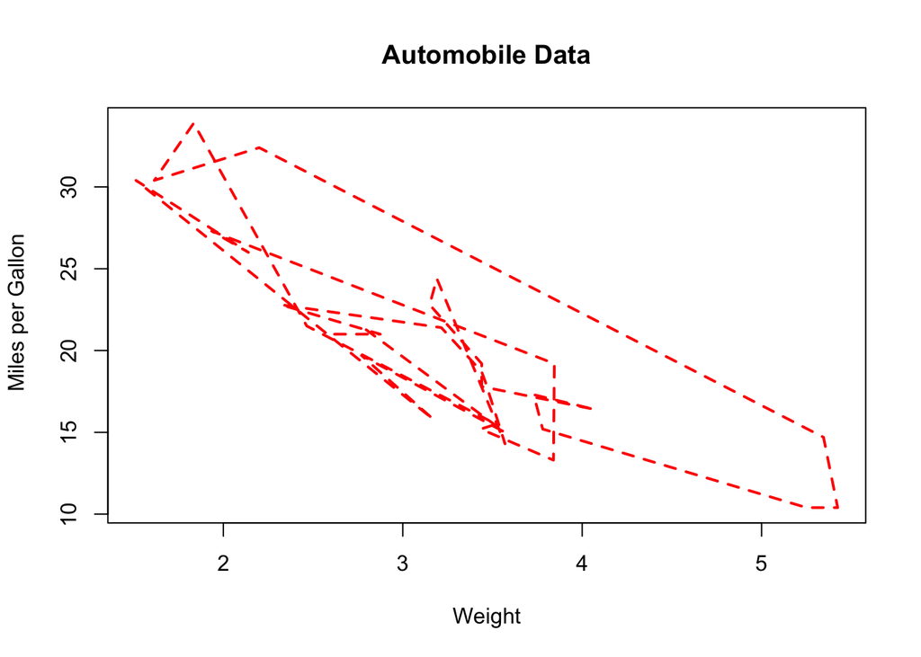

```r
plot(mtcars$mpg~mtcars$wt,type="l", lty=2, lwd=2,col="red",main="Automobile Data",xlab="Weight",ylab=" Miles per Gallon")
```

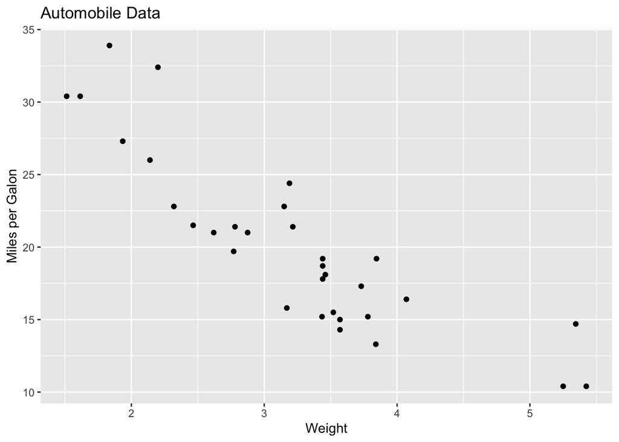

```r
 ##plot created up to that point
 library(ggplot2)
 ggplot(data=mtcars, aes(x=wt,y=mpg))+geom_point()+
 labs(title = "Automobile Data",x="Weight",y="Miles per Galon")
```

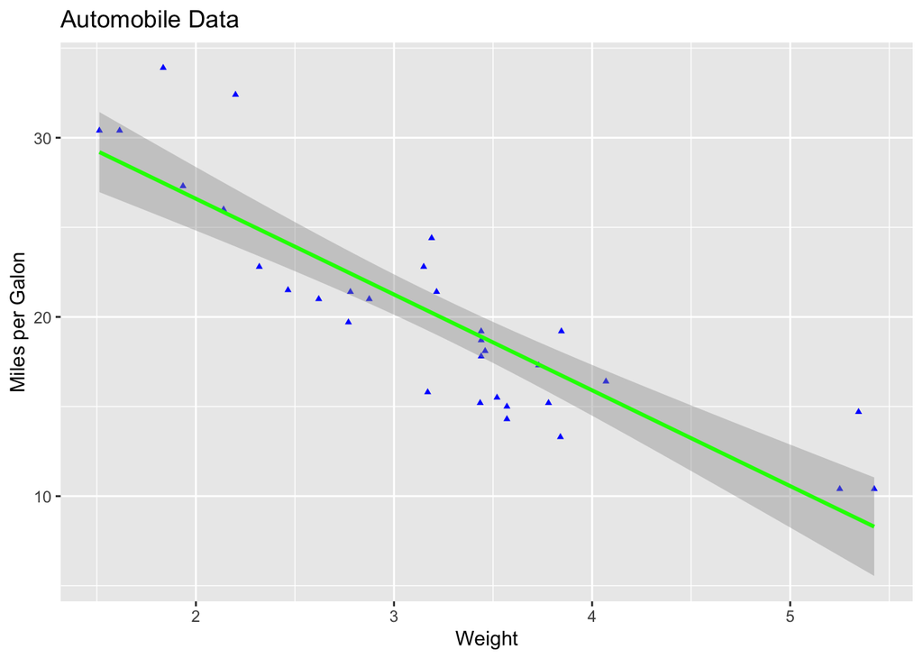

```r
ggplot(data=mtcars, aes(x=wt,y=mpg))+geom_point(pch=17,color="blue",size=1)+
 geom_smooth(method="lm",color="green")+
 labs(title = "Automobile Data",x="Weight",y="Miles per Galon")
```

```r
 ## `geom_smooth()` using formula = 'y ~ x'
```

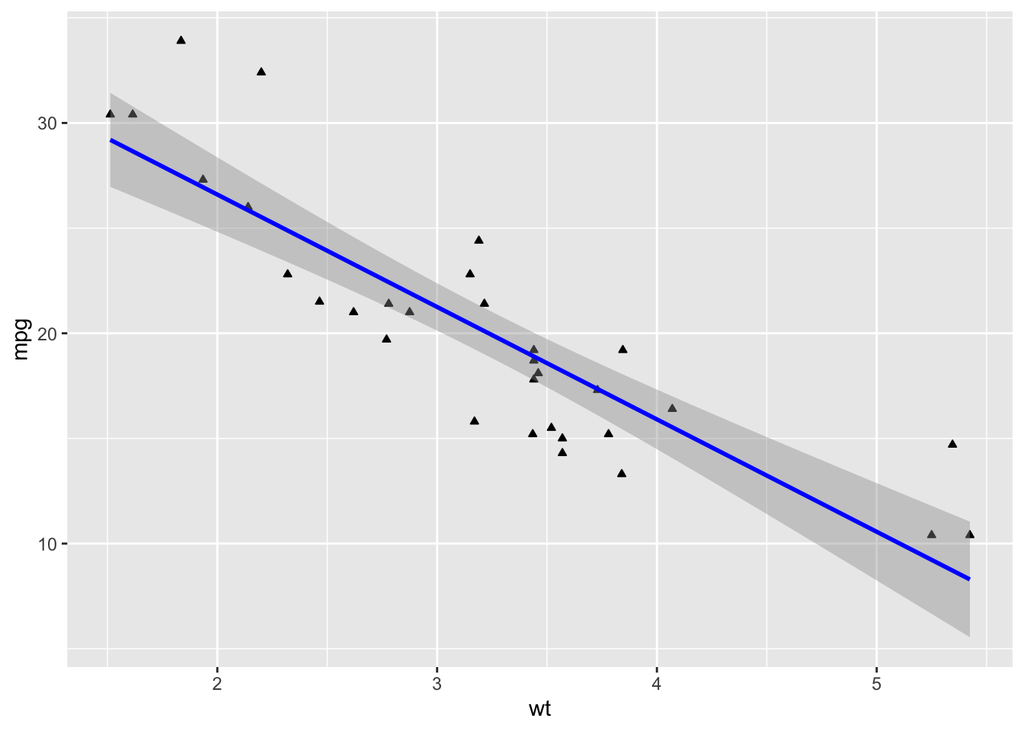

```r
f0<-ggplot(data=mtcars, aes(x=wt,y=mpg))+geom_point(shape=24, fill=1,size=1)+
 geom_smooth(method="lm",color="blue")
 f0
```

```r
 ## `geom_smooth()` using formula = 'y ~ x'
```

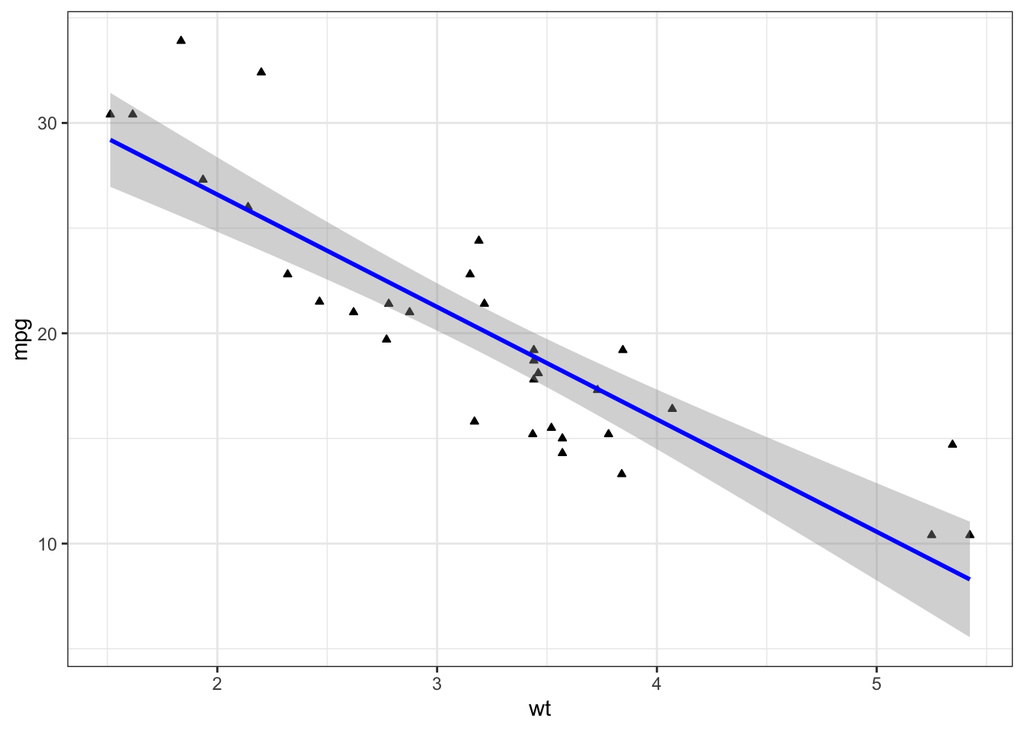

```r
f1<-f0+theme_bw()
f1
```

```r
 ## `geom_smooth()` using formula = 'y ~ x'
```

```r
f2<-f1+theme(panel.grid = element_line(linetype = "dotted",color = "Black"))
 f2
```

[figure not shown]

```r
 ## `geom_smooth()` using formula = 'y ~ x'
```

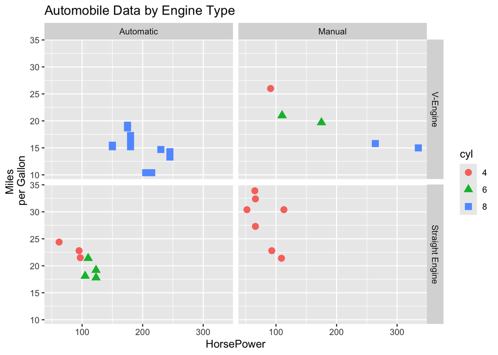

```r
data(mtcars)
 mtcars$am<-factor(mtcars$am, levels =c(0,1),
 labels= c("Automatic","Manual"))
 mtcars$vs<-factor(mtcars$vs, levels =c(0,1),
 labels=c("V-Engine","Straight Engine"))
 mtcars$cyl<-factor(mtcars$cyl)
 ggplot(data=mtcars,aes(x=hp,y=mpg,shape=cyl,color=cyl))+
 geom_point(size=3)+
 facet_grid(vs~am)+
 labs(title = "Automobile Data by Engine Type",x="HorsePower",y="Miles
 per Gallon")
```

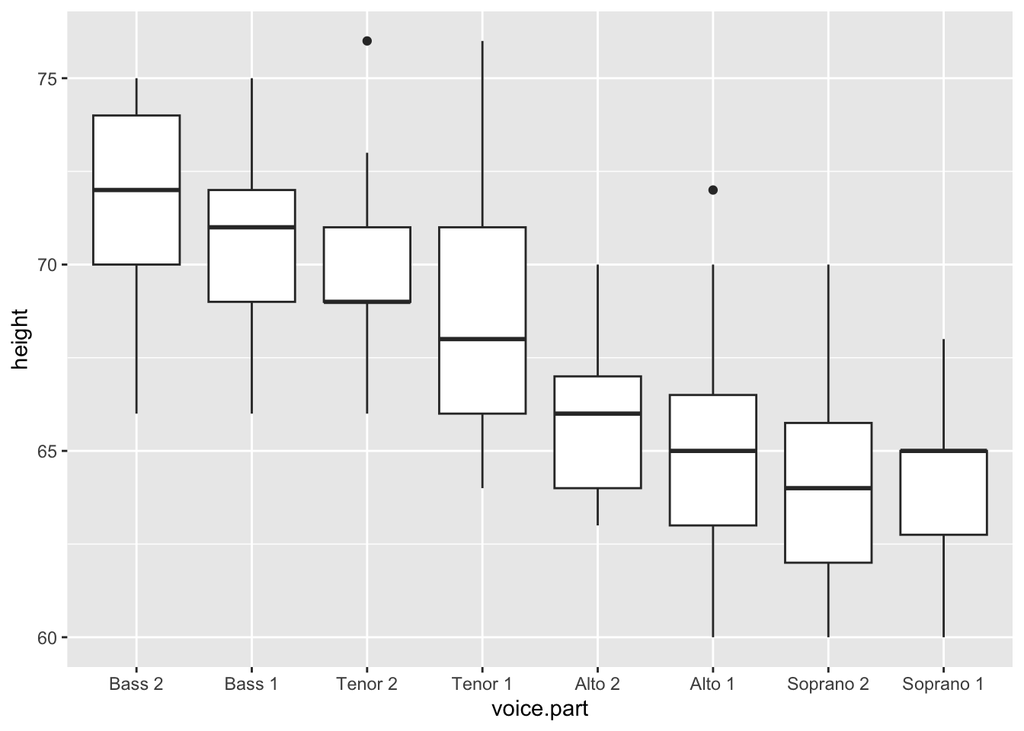

```r
data(singer,package="lattice")
 ggplot(singer,aes(x=voice.part,y=height))+geom_boxplot()
```

```r
data2<-data.frame(x=1:3,y=c("a","b","c"))
str(data2)
```

```
## 'data.frame':    3 obs. of  2 variables:
##  $ x: int  1 2 3
##  $ y: chr  "a" "b" "c"
```

```r
(cbind(data2,data.frame(z=3:1)))
```

```
##   x y z
## 1 1 a 3
## 2 2 b 2
## 3 3 c 1
```

```r
(rbind(data2,data.frame(x=10,y="z")))
```

```
##    x y
## 1  1 a
## 2  2 b
## 3  3 c
## 4 10 z
```

```r
variable.names(women)
```

```
## [1] "height" "weight"
```

```r
head(women,n=5)
```

```
##   height weight
## 1     58    115
## 2     59    117
## 3     60    120
## 4     61    123
## 5     62    126
```

```r
tail(women)
```

```
##    height weight
## 10     67    142
## 11     68    146
## 12     69    150
## 13     70    154
## 14     71    159
## 15     72    164
```

```r
women[,1]
```

```
##  [1] 58 59 60 61 62 63 64 65 66 67 68 69 70 71 72
```

```r
summary(women$WEIGHT)
```

```
## Length  Class   Mode
##      0   NULL   NULL
```

```r
length(women$WEIGHT)
```

```
## [1] 0
```

```r
women[,-1]
```

```
##  [1] 115 117 120 123 126 129 132 135 139 142 146 150 154 159 164
```

```r
## Subsetting

manager<-c(1,2,3,4,5)
country<-c("US","US","UK","UK","UK")
gender<-c("M","F","F","M","F")
age<-c(32,45,25,39,99)
q1<-c(5,3,3,3,2)
q2<-c(4,5,5,3,2)
q3<-c(5,2,5,4,1)
q4<-c(5,5,5,NA,2)
q5<-c(5,5,2,NA,1)
leadership<-data.frame(manager,country,gender,age,q1,q2,q3,q4,q5,stringsAsFactors=FALSE)
leadership<-data.frame(manager,country,gender,age,q1,q2,q3,q4,q5)
str(leadership)
```

```
## 'data.frame':    5 obs. of  9 variables:
##  $ manager: num  1 2 3 4 5
##  $ country: chr  "US" "US" "UK" "UK" ...
##  $ gender : chr  "M" "F" "F" "M" ...
##  $ age    : num  32 45 25 39 99
##  $ q1     : num  5 3 3 3 2
##  $ q2     : num  4 5 5 3 2
##  $ q3     : num  5 2 5 4 1
##  $ q4     : num  5 5 5 NA 2
##  $ q5     : num  5 5 2 NA 1
```

```r
names(leadership)
```

```
## [1] "manager" "country" "gender"  "age"     "q1"      "q2"      "q3"
## [8] "q4"      "q5"
```

```r
leadership$age[leadership$age==99]<-NA
leadership$agecat[leadership$age>75]<-"Elder"
leadership$agecat[leadership$age>=35&leadership$age<=75]<-"MiddleAged"
leadership$agecat[leadership$age<35]<-"Young"
```

```r
is.na(leadership[,5:9])
```

```
##         q1    q2    q3    q4    q5
## [1,] FALSE FALSE FALSE FALSE FALSE
## [2,] FALSE FALSE FALSE FALSE FALSE
## [3,] FALSE FALSE FALSE FALSE FALSE
## [4,] FALSE FALSE FALSE  TRUE  TRUE
## [5,] FALSE FALSE FALSE FALSE FALSE
```

```r
newdata<-na.omit(leadership)
newdata
```

```
##   manager country gender age q1 q2 q3 q4 q5     agecat
## 1       1      US      M  32  5  4  5  5  5      Young
## 2       2      US      F  45  3  5  2  5  5 MiddleAged
## 3       3      UK      F  25  3  5  5  5  2      Young
```

Sorting data

```r
order(leadership$age)
```

```
## [1] 3 1 4 2 5
```

```r
newdata2<-leadership[order(leadership$age),]
```

```r
# Subset(selectingvariables,droppingvariables,selectingobservation)
 newdata3<-leadership[,c(5:9)]
 myvars<-c("q1","q2","q3","q4","q5")
 newdata3<-leadership[myvars]
 newdata4<-leadership[,c(-1,-2)]
 newdata4<-leadership[,-(1:5)]
 newdata5<-leadership[,c(-1,-7)]
 leadership[[4]]
```

```
## [1] 32 45 25 39 NA
```

```r
leadership$age
```

```
## [1] 32 45 25 39 NA
```

```r
newdata6<-leadership[c(-1,-3),]
newdata6<-leadership[c(2,4,5),]
newdata7<-subset(leadership,age>=35|age<24,select=c(q1,q2,q3,q4,q5))
attach(leadership)
#newdata7<-leadership[gender="M"&age>30,]
 newdata7<-leadership[gender=="M"&age>30,]
 detach(leadership)
```

```r
library(nycflights13)
library(dplyr)
#library(tidyverse)
```

```r
 str(flights)
```

```
## tibble [336,776 × 19] (S3: tbl_df/tbl/data.frame)
##  $ year          : int [1:336776] 2013 2013 2013 2013 2013 2013 2013 2013 2013 2013 ...
##  $ month         : int [1:336776] 1 1 1 1 1 1 1 1 1 1 ...
##  $ day           : int [1:336776] 1 1 1 1 1 1 1 1 1 1 ...
##  $ dep_time      : int [1:336776] 517 533 542 544 554 554 555 557 557 558 ...
##  $ sched_dep_time: int [1:336776] 515 529 540 545 600 558 600 600 600 600 ...
##  $ dep_delay     : num [1:336776] 2 4 2 -1 -6 -4 -5 -3 -3 -2 ...
##  $ arr_time      : int [1:336776] 830 850 923 1004 812 740 913 709 838 753 ...
##  $ sched_arr_time: int [1:336776] 819 830 850 1022 837 728 854 723 846 745 ...
##  $ arr_delay     : num [1:336776] 11 20 33 -18 -25 12 19 -14 -8 8 ...
##  $ carrier       : chr [1:336776] "UA" "UA" "AA" "B6" ...
##  $ flight        : int [1:336776] 1545 1714 1141 725 461 1696 507 5708 79 301 ...
##  $ tailnum       : chr [1:336776] "N14228" "N24211" "N619AA" "N804JB" ...
##  $ origin        : chr [1:336776] "EWR" "LGA" "JFK" "JFK" ...
##  $ dest          : chr [1:336776] "IAH" "IAH" "MIA" "BQN" ...
##  $ air_time      : num [1:336776] 227 227 160 183 116 150 158 53 140 138 ...
##  $ distance      : num [1:336776] 1400 1416 1089 1576 762 ...
##  $ hour          : num [1:336776] 5 5 5 5 6 5 6 6 6 6 ...
##  $ minute        : num [1:336776] 15 29 40 45 0 58 0 0 0 0 ...
##  $ time_hour     : POSIXct[1:336776], format: "2013-01-01 05:00:00" "2013-01-01 05:00:00" ...
```

```r
#attach(flights)
 jan<-filter(flights,month==1)
 jan
```

```
## # A tibble: 27,004 × 19
##     year month   day dep_time sched_dep_time dep_delay arr_time sched_arr_time
##    <int> <int> <int>    <int>          <int>     <dbl>    <int>          <int>
##  1  2013     1     1      517            515         2      830            819
##  2  2013     1     1      533            529         4      850            830
##  3  2013     1     1      542            540         2      923            850
##  4  2013     1     1      544            545        -1     1004           1022
##  5  2013     1     1      554            600        -6      812            837
##  6  2013     1     1      554            558        -4      740            728
##  7  2013     1     1      555            600        -5      913            854
##  8  2013     1     1      557            600        -3      709            723
##  9  2013     1     1      557            600        -3      838            846
## 10  2013     1     1      558            600        -2      753            745
## # ℹ 26,994 more rows
## # ℹ 11 more variables: arr_delay <dbl>, carrier <chr>, flight <int>,
## #   tailnum <chr>, origin <chr>, dest <chr>, air_time <dbl>, distance <dbl>,
## #   hour <dbl>, minute <dbl>, time_hour <dttm>
```

```r
newyear<-filter(flights,month==1,day==1)
 newyear
```

```
## # A tibble: 842 × 19
##     year month   day dep_time sched_dep_time dep_delay arr_time sched_arr_time
##    <int> <int> <int>    <int>          <int>     <dbl>    <int>          <int>
##  1  2013     1     1      517            515         2      830            819
##  2  2013     1     1      533            529         4      850            830
##  3  2013     1     1      542            540         2      923            850
##  4  2013     1     1      544            545        -1     1004           1022
##  5  2013     1     1      554            600        -6      812            837
##  6  2013     1     1      554            558        -4      740            728
##  7  2013     1     1      555            600        -5      913            854
##  8  2013     1     1      557            600        -3      709            723
##  9  2013     1     1      557            600        -3      838            846
## 10  2013     1     1      558            600        -2      753            745
## # ℹ 832 more rows
## # ℹ 11 more variables: arr_delay <dbl>, carrier <chr>, flight <int>,
## #   tailnum <chr>, origin <chr>, dest <chr>, air_time <dbl>, distance <dbl>,
## #   hour <dbl>, minute <dbl>, time_hour <dttm>
```

```r
dec25<-filter(flights,month==12,day==25)
 dec25
```

```
## # A tibble: 719 × 19
##     year month   day dep_time sched_dep_time dep_delay arr_time sched_arr_time
##    <int> <int> <int>    <int>          <int>     <dbl>    <int>          <int>
##  1  2013    12    25      456            500        -4      649            651
##  2  2013    12    25      524            515         9      805            814
##  3  2013    12    25      542            540         2      832            850
##  4  2013    12    25      546            550        -4     1022           1027
##  5  2013    12    25      556            600        -4      730            745
##  6  2013    12    25      557            600        -3      743            752
##  7  2013    12    25      557            600        -3      818            831
##  8  2013    12    25      559            600        -1      855            856
##  9  2013    12    25      559            600        -1      849            855
## 10  2013    12    25      600            600         0      850            846
## # ℹ 709 more rows
## # ℹ 11 more variables: arr_delay <dbl>, carrier <chr>, flight <int>,
## #   tailnum <chr>, origin <chr>, dest <chr>, air_time <dbl>, distance <dbl>,
## #   hour <dbl>, minute <dbl>, time_hour <dttm>
```

```r
jan_dec<-filter(flights,month==1|month==12)
 jan_dec
```

```
## # A tibble: 55,139 × 19
##     year month   day dep_time sched_dep_time dep_delay arr_time sched_arr_time
##    <int> <int> <int>    <int>          <int>     <dbl>    <int>          <int>
##  1  2013     1     1      517            515         2      830            819
##  2  2013     1     1      533            529         4      850            830
##  3  2013     1     1      542            540         2      923            850
##  4  2013     1     1      544            545        -1     1004           1022
##  5  2013     1     1      554            600        -6      812            837
##  6  2013     1     1      554            558        -4      740            728
##  7  2013     1     1      555            600        -5      913            854
##  8  2013     1     1      557            600        -3      709            723
##  9  2013     1     1      557            600        -3      838            846
## 10  2013     1     1      558            600        -2      753            745
## # ℹ 55,129 more rows
## # ℹ 11 more variables: arr_delay <dbl>, carrier <chr>, flight <int>,
## #   tailnum <chr>, origin <chr>, dest <chr>, air_time <dbl>, distance <dbl>,
## #   hour <dbl>, minute <dbl>, time_hour <dttm>
```

```r
nov_dec<-filter(flights,month%in%c(11,12))
 #detach(flights)
```

```r
data_10<-arrange(flights,year,month,day)
 arrange(flights,desc(arr_delay))
```

```
## # A tibble: 336,776 × 19
##     year month   day dep_time sched_dep_time dep_delay arr_time sched_arr_time
##    <int> <int> <int>    <int>          <int>     <dbl>    <int>          <int>
##  1  2013     1     9      641            900      1301     1242           1530
##  2  2013     6    15     1432           1935      1137     1607           2120
##  3  2013     1    10     1121           1635      1126     1239           1810
##  4  2013     9    20     1139           1845      1014     1457           2210
##  5  2013     7    22      845           1600      1005     1044           1815
##  6  2013     4    10     1100           1900       960     1342           2211
##  7  2013     3    17     2321            810       911      135           1020
##  8  2013     7    22     2257            759       898      121           1026
##  9  2013    12     5      756           1700       896     1058           2020
## 10  2013     5     3     1133           2055       878     1250           2215
## # ℹ 336,766 more rows
## # ℹ 11 more variables: arr_delay <dbl>, carrier <chr>, flight <int>,
## #   tailnum <chr>, origin <chr>, dest <chr>, air_time <dbl>, distance <dbl>,
## #   hour <dbl>, minute <dbl>, time_hour <dttm>
```

```r
time_var<-select(flights,year,month,day)
 select(flights,year:day)
```

```
## # A tibble: 336,776 × 3
##     year month   day
##    <int> <int> <int>
##  1  2013     1     1
##  2  2013     1     1
##  3  2013     1     1
##  4  2013     1     1
##  5  2013     1     1
##  6  2013     1     1
##  7  2013     1     1
##  8  2013     1     1
##  9  2013     1     1
## 10  2013     1     1
## # ℹ 336,766 more rows
```

```r
 select(flights,-(year:day))
```

```
## # A tibble: 336,776 × 16
##    dep_time sched_dep_time dep_delay arr_time sched_arr_time arr_delay carrier
##       <int>          <int>     <dbl>    <int>          <int>     <dbl> <chr>
##  1      517            515         2      830            819        11 UA
##  2      533            529         4      850            830        20 UA
##  3      542            540         2      923            850        33 AA
##  4      544            545        -1     1004           1022       -18 B6
##  5      554            600        -6      812            837       -25 DL
##  6      554            558        -4      740            728        12 UA
##  7      555            600        -5      913            854        19 B6
##  8      557            600        -3      709            723       -14 EV
##  9      557            600        -3      838            846        -8 B6
## 10      558            600        -2      753            745         8 AA
## # ℹ 336,766 more rows
## # ℹ 9 more variables: flight <int>, tailnum <chr>, origin <chr>, dest <chr>,
## #   air_time <dbl>, distance <dbl>, hour <dbl>, minute <dbl>, time_hour <dttm>
```

```r
##createasmalldataset
 flights2<-select(flights,year:day,ends_with("delay"),distance,air_time)
 (mutate(flights2,gain=arr_delay-dep_delay,speed=distance/air_time*60))
```

```
## # A tibble: 336,776 × 9
##     year month   day dep_delay arr_delay distance air_time  gain speed
##    <int> <int> <int>     <dbl>     <dbl>    <dbl>    <dbl> <dbl> <dbl>
##  1  2013     1     1         2        11     1400      227     9  370.
##  2  2013     1     1         4        20     1416      227    16  374.
##  3  2013     1     1         2        33     1089      160    31  408.
##  4  2013     1     1        -1       -18     1576      183   -17  517.
##  5  2013     1     1        -6       -25      762      116   -19  394.
##  6  2013     1     1        -4        12      719      150    16  288.
##  7  2013     1     1        -5        19     1065      158    24  404.
##  8  2013     1     1        -3       -14      229       53   -11  259.
##  9  2013     1     1        -3        -8      944      140    -5  405.
## 10  2013     1     1        -2         8      733      138    10  319.
## # ℹ 336,766 more rows
```